# Exploration of Red Wine Attributes

# Multivariate Plots Section

From the exploration and analysis so far, it appears that the most influencing factors are alcohol content, the amount of Sulphates, volatile aciditiy and even citric acid. We will review them further.

Since alcohol is a quantitative variable, We created a variable called alcohol.buckets and separated the variable into different alcohol ranges or bins. This was to better determine the effect and trends with the other variables.

```
##
##   [8,9]  (9,10] (10,11] (11,12] (12,15]
##      37     710     444     267     141
```

We verified the bin ranges. We see that for wines with alcohol content more that 10% and less than or equal to 11%, the count is 444 wines.

```
##   [8,9]  (9,10] (10,11] (11,12] (12,15]
##      37     710     444     267     141
```

```
## [1] 444
```

NOTE: The bin values range from greater than the lower limit to inclusive of the upper limit.

We also created bins for sulphates amounts. We used the statistics values to help determine how to separate the bin ranges.

```
##    Min. 1st Qu.  Median    Mean 3rd Qu.    Max.
##  0.3300  0.5500  0.6200  0.6581  0.7300  2.0000
```

```
## sulphates.buckets
##  [0.33,0.55] (0.55,0.658] (0.658,0.73]     (0.73,2]
##          420          544          249          386
```

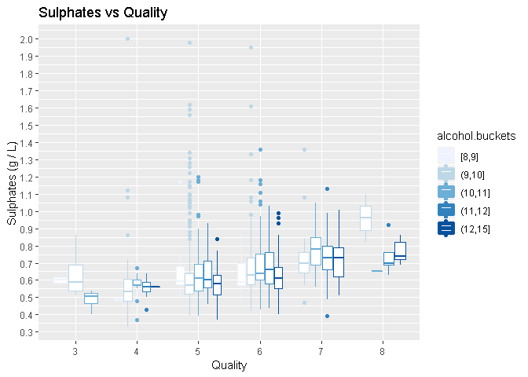

This plot shows that on average the amount of Sulphates is greater in wines with higher ratings despite the alcohol content. However, it shows that wines that received a quality rating of 3, have an alcohol content below 11%. In addition, the Sulphates amount was about 0.75 g/L at the most except for wines of more than 9.0% to 10% alcohol content. These wines when having a rating of 8 had the highest Sulphate amount of about 0.95 g/L.

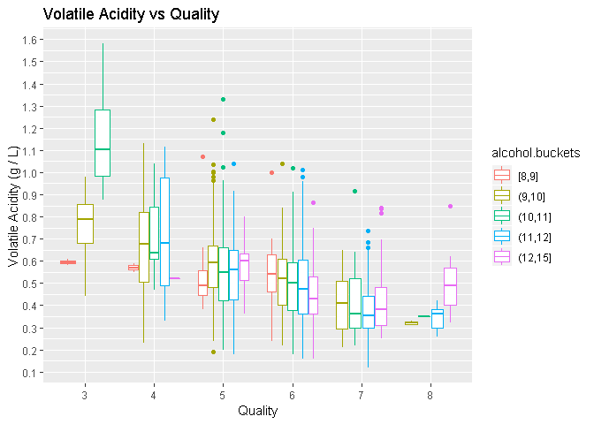

As we seen the wines with lower volatile acidity received the highest ratings regardless of alcohol content. The wines with a rating of 8 had a volatile acidity of approximately 0.3 g/L to 0.5 g/L except for wines with greater than 12% alcohol content.

The range of the pH values are shown below.

```
## [1] 2.74 4.01
```

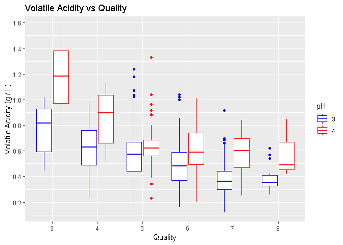

An overview plot of the wines with a pH of 3 and 4 (when rounded) is shown above. We see that more acidic wines (pH ~ 3) had less volatile acidity for each rating compared to wines with less acidic wines. Generally, for wines with a rounded pH value of 3, the volatile acidity ranged from about 0.35 g/L to 0.8 g/L while wine with a rounded pH value of 4 ranged from about 0.5 g/L to 1.2 g/L.

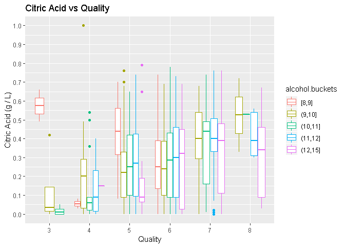

We then look at the influence of citric acid and alcohol. It appears that the two highest rated wines (7 and 8) shows a citric acid amount ranged from about 0.35 g/L to less than 0.55 g/L While the lower rated wines had a lower amount except for wines with an alcohol content between 8 and 9%. Two of the lower rated wines (3 and 5) had a citric acid amount of about 0.58 and 0.45, respectively.

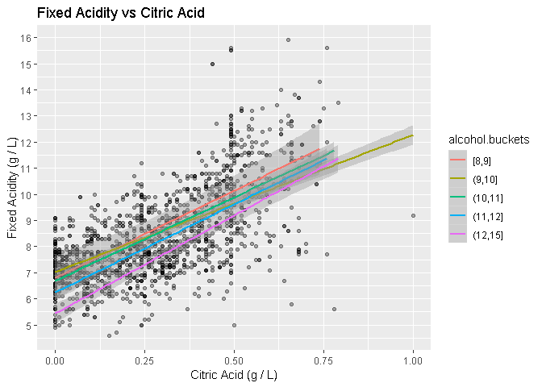

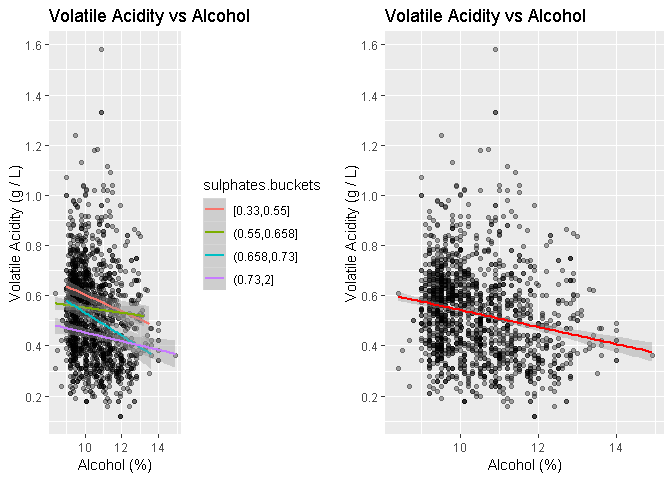

The plots reflect that on average that wines with lower Sulphates amounts have higher volatile acidity. The rightmost plot also showed a general trend line.

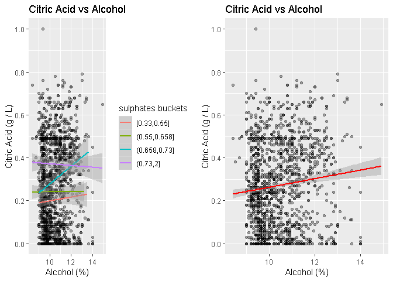

In the plot above, it appears that on average, the higher the Sulphates amount, the higher the citric acid. In addition, there is a slight increase with higher alcohol content except for the highest Sulfates level, which shows a decrease. We see that there is great increase with alcohol content with one of the Sulphates ranges of 0.658 to 0.73.

# Multivariate Analysis

### Talk about some of the relationships you observed in this part of the investigation. Were there features that strengthened each other in terms of looking at your feature(s) of interest?

Upon review, we see that more acidic wines (pH ~ 3) had less volatile acidity for each rating compared to wines with less acidic wines. In addition, wines with less volatility had higher amounts of Sulphates.

Another relationship was that between citric acid and Sulphates. Overall, wines with higher amounts of citric acid also had higher amounts of Sulphates. In addition, on average these amounts for both substances increase with an increase of alcohol content.

### Were there any interesting or surprising interactions between features?

It appears that as the volatile acidity decreases the quality rating increases despite the alcohol content.

# Final Plots and Summary

### Plot One

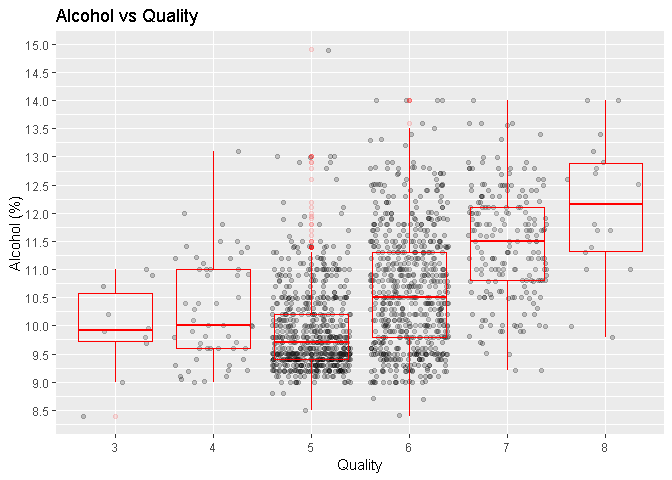

### Description One

The plot above shows that the wines that received the higher quality ratings had a higher alcohol content. Except for the rating value of 5, the plot shows a positive trend where the quality rating tend to increase as the alcohol content increases.

### Plot Two

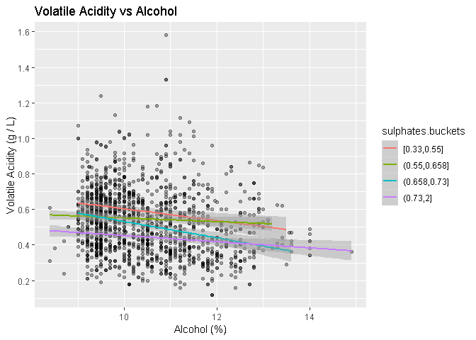

### Plot Three

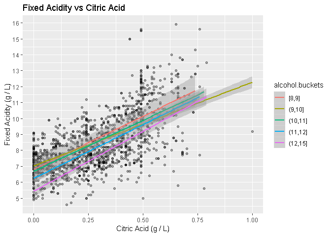

# Reflection

Wines greater than 45 g/L are considered sweet according to the database wine information. However, the maximum residual sugar shown is 15.5 g/L, so none of the wines are considered sweet. The attribute residual sugar did not seem to have a significant influence on the quality score of the wine. Maybe wines with a higher or more detectable residual sugar content would be more likeable and have more affect on the quality of the wines.

From the analysis of this particular dataset, the alcohol content appears to be the most significant variable influencing the quality rating given to the wine. Overall, there is a positive relationship between these two variables. The other sigificant variables were citric acid, volatile acidity, amount of Sulphates, and fixed acidity. Overall, the wines with the highest quality ratings have higher alcohol content, higher amounts of Sulphates, lower volatile acidity, lower fixed acidity, and higher citric acid. It appears that various acidity measures are significant to the wine quality.

The analysis had several seemingly influencing variables and there was some difficulty with deciding which ones to focus on and which to compare with each other. Using the correlation function and linear regression helped with these decisions. This analysis would be enriched with variables like the weather, the region the grapes were grown or the wine was made, and the year in which the wine was made.

Sources:  
+ stackoverflow.com  
+ r-blogger.com  
+ youtube.com  
+ http://kbroman.org/knitr_knutshell/pages/Rmarkdown.html  
+ http://www.sthda.com/english/wiki/visualize-correlation-matrix-using-correlogram  
+ https://rstudio.github.io/dygraphs/r-markdown.html